# Off the Hook

Disasters and the Absence of Accountability in Authoritarian Russia

Noah Buckley

Trinity College Dublin

September 1, 2026

## When disaster strikes under autocracy

- Autocracies lean on **performance** to legitimate themselves — and disasters are exogenous tests of that performance (Gerschewski 2013)
- So when a disaster strikes, does the public hold the regime to account?
  - Democratic accountability: voters **punish** poor performance (Healy & Malhotra 2009; Gasper & Reeves 2011)
  - But Lazarev et al. (2014): the 2010 wildfires **raised** support for the authorities — a *rally*
- Both are claims about an **average effect**. Which one wins?

## What we know and what we don’t

- Rich work on authoritarian responsiveness: blame attribution (Reuter & Beazer 2019; Buckley et al. 2022), affective bonds (Greene & Robertson 2019; Frye 2021)
- A single, striking result on disasters: the Lazarev *rally* (Lazarev et al. 2014)
- But the record is **contradictory**, and almost all of it rests on:
  - one event, or one region, or
  - an *average* effect estimated without a clean identification check
- No multi-event, micro-level test of disaster accountability in an autocracy

## Research questions

1. Does exposure to a local disaster shift **support** for the regime (Putin) or its **agents** (governors)?
2. Is any apparent effect **causal** — or an artifact of *which* region-months get recorded as having disasters?

## What I find

Authoritarian publics do not hold the regime to account for disasters.

# Data & design

## Disaster data

- **4,235** disasters and accidents, 2012–2022, 84 regions
- Built from FPP regional digests (≈95,000 raw events)
  - hand-coding **+** LLM classification **+** rule-based and LLM filters
- Deliberately **broad**: fires, floods, industrial and mining accidents, transport, gas explosions, mass poisonings, infrastructure failures
- Each event: death toll, ordinal severity, ex-ante government responsibility, type
- **External validation**
  - recovers 96% of well-known Wikipedia-listed disasters
  - corroborates with the EM-DAT registry
  - 89% recall / 85% non-disaster catch on a hand-coded sample

Source: FPP regional digests, 2012–2022

## Survey data

- Pooled, harmonized Russian public opinion data — Levada, VTsIOM, FOM
  - **≈ 5.2 million** responses, 1993–2024 (restricted here to 2012+)
  - interview date and region for every respondent
- Outcomes (dichotomous):
  1. Approval of **Putin** — diffuse / regime-level support
  2. Approval of the **governor** — specific / lower-level support (Easton 1965)
- Plus the daily VTsIOM “Sputnik” survey (≈3.3M, 2018–2024) for high-frequency event studies

## Estimation

**Individual-level difference-in-differences**

- Linear probability model — OLS with two-way fixed effects
- Fixed effects: **region, year-month**, survey source, locality size
- SEs clustered by region

**Treatment:** a disaster in the respondent’s region in the last **14 / 30 days**

- Identification comes off **local exposure** — whether a disaster recently struck *your* region
- Parallel trends is untestable, so I lean on a **pre-event placebo**

## The key diagnostic: a pre-event placebo

**A disaster that has not happened yet cannot move current approval.**

- So I also estimate the effect of a disaster in the **next** 30 days — a *forward* placebo
- If the “forthcoming” disaster predicts approval as well as the past one, the estimate reflects **selection in which region-months get recorded** as having disasters — not a causal response

# Results

## The average effect is a null

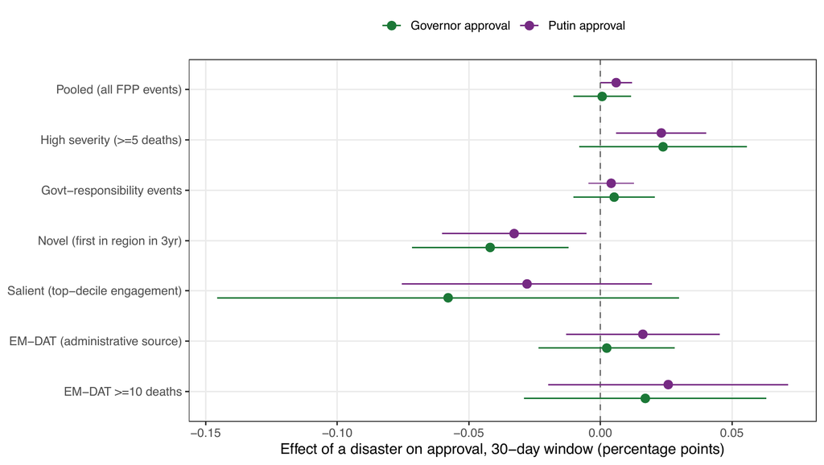

## The average effect is a null

*DV: approval. “Placebo” = a disaster in the next 30 days. SEs clustered by region.*

|  | Putin: effect | Putin: placebo | Gov: effect | Gov: placebo |
| --- | --- | --- | --- | --- |
| Disaster, 30d | **0.006**<sup>+</sup> | 0.004 | 0.001 | 0.005 |
|  | (0.003) | (0.004) | (0.006) | (0.006) |
| Region / month / source FE | ✓ | ✓ | ✓ | ✓ |
| $N$ | 1,066,957 | 1,066,957 | 329,988 | 329,988 |

- The one marginally-positive coefficient (Putin, +0.6pp) is **matched by its pre-event placebo** (+0.4pp)
- <sup>+</sup> p<0.1

## Naive estimates are confounded

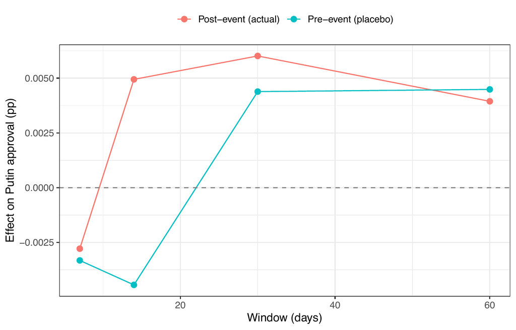

## Naive estimates are confounded

The “rally” and the “punishment” are the same confounded association, sliced two ways.

- Plausibly the attention of media compilers is already trained on these region-months — the *disasters* are exogenous, but their **recording** is not

## Cross-source confirmation

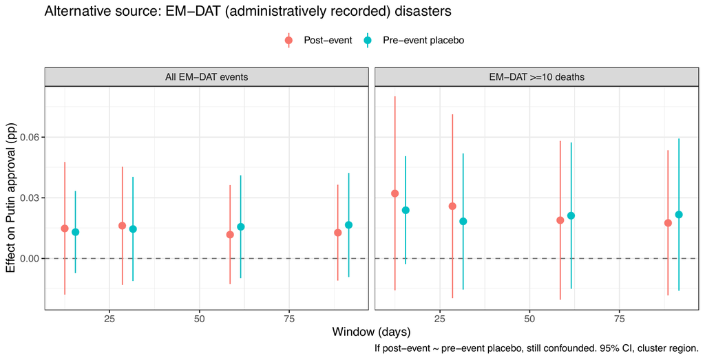

- The FPP source is media-selected — so I re-estimate with **administrative** sources:
  - **EM-DAT** (international registry; deaths/affected/emergency thresholds)
  - **EMERCOM** (emergency-service counts)
- Both are far less attention-driven. Both are **null**, with the pre-event placebo tracking the estimate.

## No moderator survives

The pre-registered moderators **and** an extended battery:

- **Severity** thresholds (deaths ≥ 5, ≥ 10) — confounded, not causal
- **Salience** — eight measures of local vs. national attention
- **Novelty** — six ways of coding “surprise”
- **Event type** — fires, floods, industrial, transport, … one at a time
- **Period** — performance vs. ideological legitimation eras
- **Respondents** — age, urban/rural, internet vs. TV

Nothing produces a robust effect that survives the placebo.

## Is it just underpowered? No

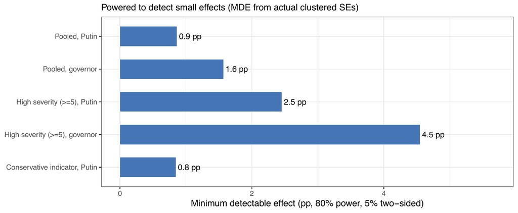

## Is it just underpowered? No

The null is informative, not a power failure.

## The earlier period, and Lazarev

- The event data begin in 2012; surveys and EM-DAT reach back further
- In the **earlier, performance-legitimation period**, severe events show a **rally** — directionally consistent with Lazarev et al. (2014) (Lazarev et al. 2014)
- But it does **not generalize**:
  - the timing is episodic, not a clean break
  - it does not survive comprehensive, FPP-comparable event measurement
- An honest, fragile, *severe-event-only* footnote — not the headline

# Discussion

## Why is there no accountability?

- A candidate reading: the **blame channel is severed**
  - heavy state control of the information environment
  - a regime that legitimates increasingly through ideology, not performance
- Suggestive: the **pollster split** — Levada (−) vs. VTsIOM (+). *Who* asks shapes what you see
- The public clearly **notices** disasters; approval simply does not move — attention without accountability
- I read this *tentatively*. It motivates mechanism work; it is not tested here.

## Conclusions

- No measurable accountability for disasters in Putin-era Russia — even severe, government-implicated ones — across **three** data sources
- Naive estimates mislead: a “rally” and a “punishment” are confounded artifacts of event recording
- A methodological caution for observational disaster–opinion designs: **run the pre-event placebo**

**Future work**

- Direct mechanism tests (internet vs. TV; media framing)
- A continuous measure of regime framing (performance vs. ideology)
- High-salience post-2024 cases (e.g., the Kerch oil spill)

## Thank you

**Noah Buckley** · Trinity College Dublin

noah.buckley@tcd.ie · noahbuckley.github.io

*Questions?*

# Appendix

## High-severity events: effect vs. placebo

*Deaths ≥ 5. The larger Putin estimate is matched by a comparable pre-event placebo.*

|  | Putin: effect | Putin: placebo | Gov: effect | Gov: placebo |
| --- | --- | --- | --- | --- |
| High-severity, 30d | **0.023**** | 0.014<sup>+</sup> | 0.024 | 0.000 |
|  | (0.009) | (0.008) | (0.016) | (0.016) |
| Region / month / source FE | ✓ | ✓ | ✓ | ✓ |
| $N$ | 1,066,957 | 1,066,957 | 329,988 | 329,988 |

<sup>+</sup> p<0.1, ** p<0.01

## Earlier-period rally (Courier × EM-DAT)

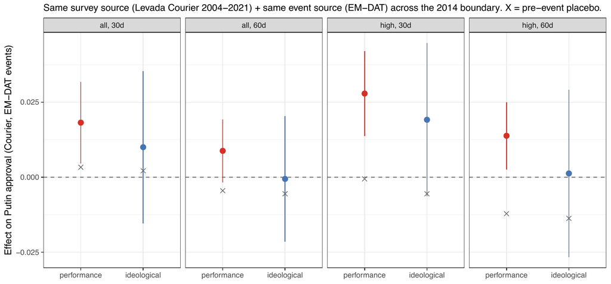

## Cluster-robust inference

- 84 region clusters; CR1 inference is adequate
- Two-way (region $\times$ month) clustering does **not** weaken the marginal Putin positive — it *sharpens* it ($p \approx 0.05 \rightarrow 0.01$)
- So the null causal reading rests on the **placebo**, not the standard error: a precisely-estimated positive matched by an equally-positive pre-event placebo is *more* clearly selection